# Heatmap examples using image.biom()

The generic `image()` function is defined by `matR` for class `biom` to produce a heatmap-dendrogram. Heatmaps of raw counts are typically not very revealing. A log transformation makes interesting things more apparent.

```r
library(matR)
xx1t <- transform (xx1, t_Log)
xx2t <- transform (xx2, t_Log)
```

A title is the simplest of graphical adjustments you may want to make.

```r
# image (xx2t, main="title")
```

As with other functions, metadata can be directed substituted in some places with the `$$` shorthand.

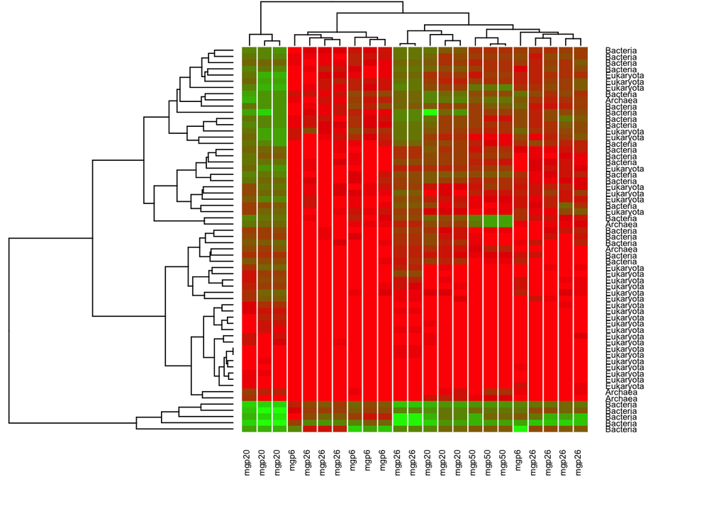

```r
image (xx2t, labCol="$$project.id", labRow="$$taxonomy1")
```

Like other matR functions and indeed all graphics in R, this is a layer built upon other layers. Heatmaps, more than any other analysis, may require fiddling with margins. The most important settings for this are shown now. Under `?heatmap.2` read about `margins`, `lwid`, and `lhei` especially. Unfortunately, getting the knack of adjusting them is a trial-and-error process. Of necessity, they’re used repeatedly in the rest of the tutorial.

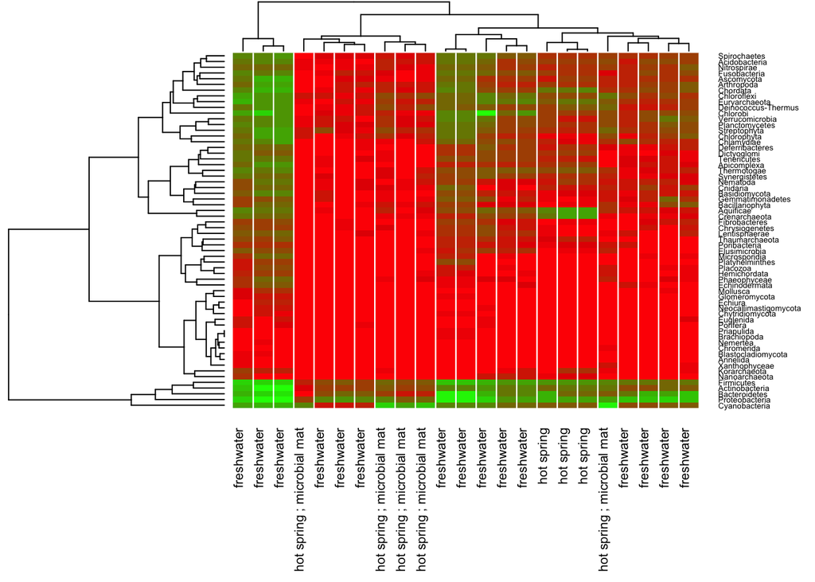

```r
image (xx2t,
    labCol="$$material",
    margins=c(9,6),
    lwid=c(1,2.5),lhei=c(1,10),
    cexRow=0.5,cexCol=0.8)
```

Setting `rows=` and/or `columns=` allows a partial heatmap.

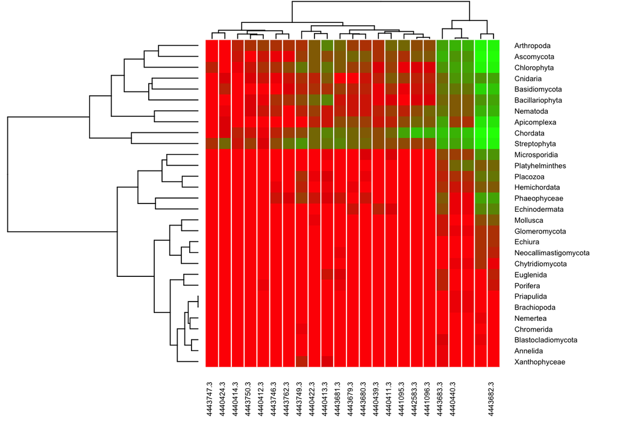

```r
image (xx2t, labCol="$$metagenome.id", labRow="$$taxonomy2", rows=rows(xx2t,"taxonomy1")=="Eukaryota")
```

Of course, an alternate way to accomplish the same thing is to select part of the `biom` object explicitly.

[figure not shown]

```r
image (xx2t [rows(xx2t,"taxonomy1")=="Eukaryota", columns(xx2t,"project.id")=="mgp20"])
```

The dendrogram can be omitted (in which case it helps to trim all the whitespace left vacant).

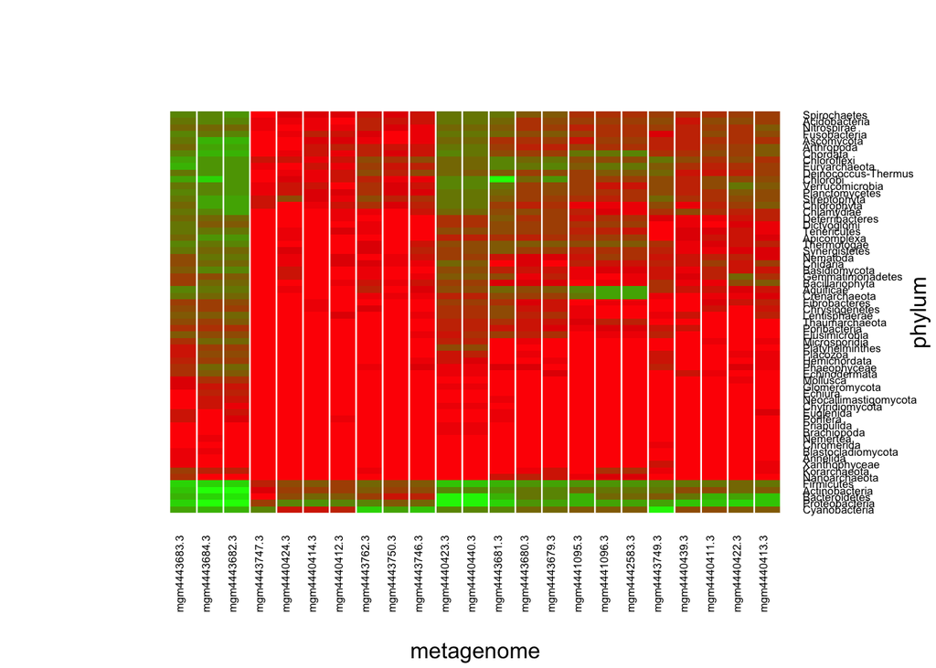

```r
# image (xx2t, dendrogram="none")
image (xx2t, dendrogram="none", lwid=c(2,9), lhei=c(2,10), margins=c(7,7), xlab="metagenome", ylab="phylum")
```

Here’s a heatmap with many more rows than previous examples.

```r
nrow(xx1t)
```

```
## rows
##  161
```

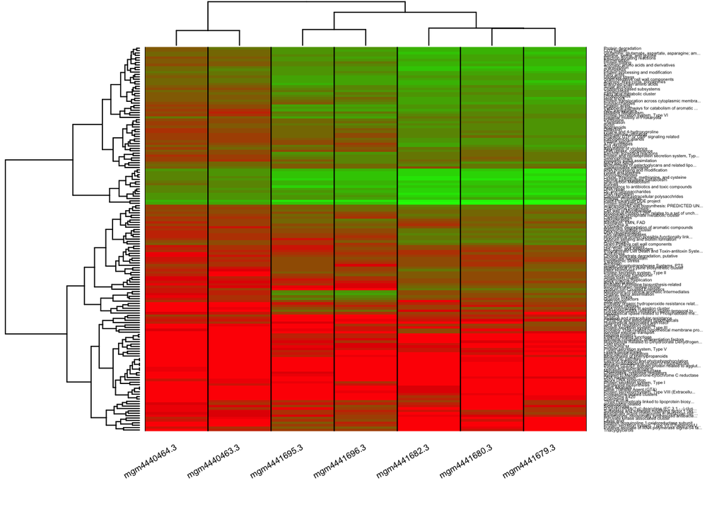

```r
image(xx1t, labRow=matR:::abbrev(rownames(xx1t),50), srtCol=30, cexRow=0.3, sepcol="black", sepwidth=c(0.001,0), colsep=0:(ncol(xx1t)+1), rowsep=NULL, lwid=c(1,4))
```

Changing the color scheme is easy. Here we use some predefined colors that were generated with the nice interactive utility `colorspace::choose_palette()`.

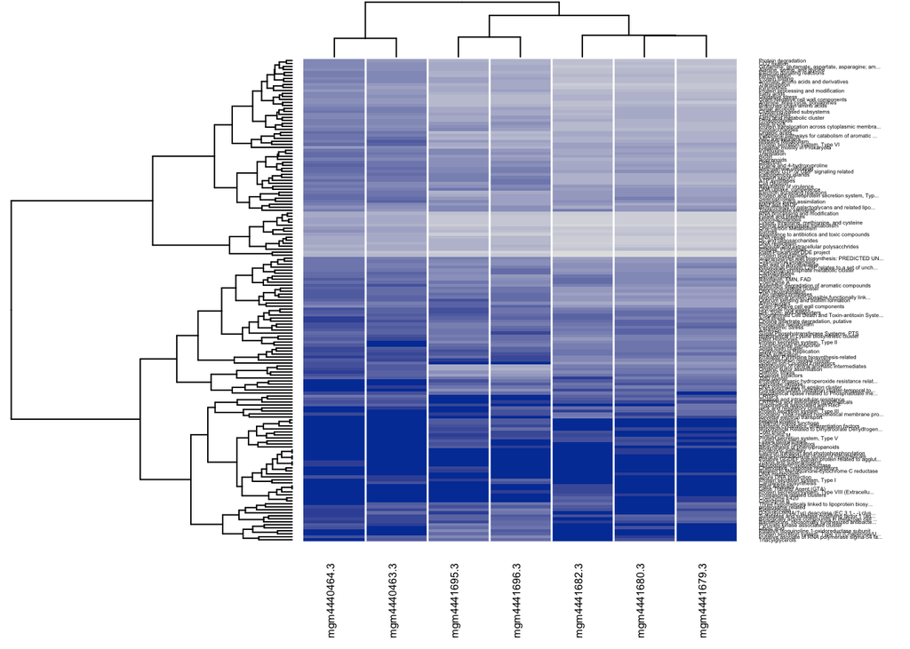

```r
blue_palette <- c("#023FA5", "#2949A4", "#3B53A6", "#495DA8", "#5666AB", "#6170AF", "#6C79B3", "#7781B7",
"#818ABB", "#8A92BE", "#939BC2", "#9CA2C6", "#A5AAC9", "#ADB1CD", "#B5B8D0", "#BCBFD3", "#C3C5D6",
"#C9CBD8", "#CFD1DB", "#D5D6DD", "#D9DADF", "#DDDEE0", "#E1E1E2", "#E2E2E2")
image(xx1t, labRow=matR:::abbrev(rownames(xx1t),50), cexRow=0.3, col=blue_palette)
```

Optionally, a combined color key and histogram of annotation count values can be plotted.

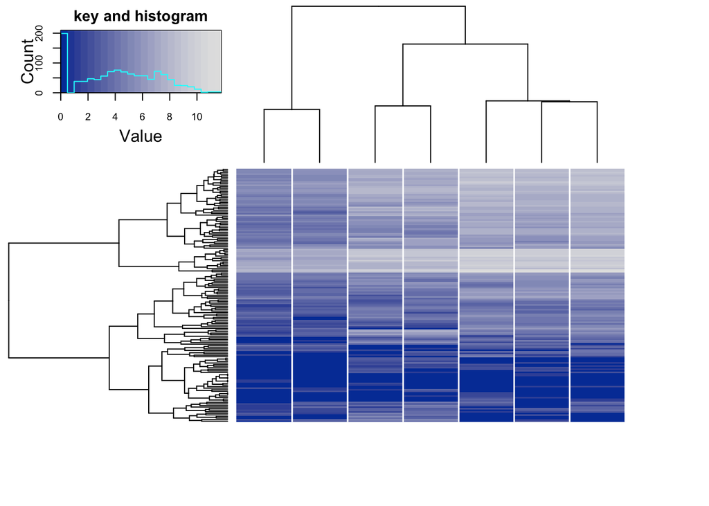

```r
image(xx1t, col=blue_palette, key=TRUE, lwid=c(1,2),lhei=c(1,2),
    margins=c(5,5),
    labRow=NA, labCol=NA,
    key.title="key and histogram",
    key.par=list(cex.axis=0.8))             # not all working: cex.lab=0.8, cex.main=0.8, cex.axis=0.6
```

```r
p <- rowstats (xx2t, test="t-test-unpaired", groups="$$material") $ p.value
p [is.na(p)] <- p [is.nan(p)] <- FALSE
# then we would restrict rows as above:
# image (xx2t [rows = p < 0.05, ], labCol="$$material")
```